# TP2

Vivien

23/05/2021

# Level 1

implement the least squares estimator $\hat \beta$ of the parametric component with a given kernel (e.g. naive) and a given bandwidth $h$.

On utlise la représentation matricielle :

$\hat \beta = [X^t(I_n-S)²X]^{-1}X^t(I_n-S)²Y$

```r
X <- cbind(apartments$construction.date, apartments$surface)
X_t <- t(X)
n <- length(X[,1])
I_n <- diag(x = 1, nrow = n, ncol =n)
Y <- apartments$transaction.price
Z <- apartments$n.rooms


denominateur_S <- c()
for (i in 1:n) {
  denominateur_S <- c(denominateur_S, sum(sapply((Z - Z[i])/h, K_naif)))
  }

S <- matrix(data = NA, nrow = n, ncol = n)
for (i in 1:n) {
  for (j in 1:n) {
    S[i,j] <-  (K_naif((Z[i] - Z[j])/h))/denominateur_S[i]
  }
}
```

Soient :

_ X comportant la date de construction et la surface _ Y le prix de du bien immobilier _ Z le nombre de pièces

```r
Beta_chapeau <- solve(X_t %*% (I_n - S)**2 %*% X) %*% X_t %*% (I_n - S)**2 %*% Y
```

On trouve les coefficients suivants pour la date de la construction et la surface :

-56.0268996, 1.1051310^{4}

# Level 2

Write a function, whose arguments should be a sample of data, a vector $b$ and a point $z$, which returns the kernel estimator of the regression function $\mathbb E(Y - X^T b| Z = z)$ at the point $z$ with this same kernel and bandwidth.

Il ne nous reste plus qu’à estimer la fonction g à travers la formule suivante :

$\hat g(z) = \frac{\sum_{j=1}^n (Y_j-X_j \hat \beta)K \left( \frac{Z_j-z}{h} \right)}{K \left( \frac{Z_j-z}{h} \right)}$

```r
Different_Z <- Z[duplicated(Z)==FALSE]
numerateur_g <- c()
denominateur_g <- c()

g_chapeau <- function(gY = Y, gX = X, gZ = Z, b = Beta_chapeau, z, gh = h){
  for (i in 1:n) {


  numerateur_g <- c(numerateur_g, (gY[i] - t(gX)[,i] %*% b) * K_naif( (gZ[i] - z) /gh) )
  denominateur_g <- c(denominateur_g, K_naif( (gZ[i] - z) /gh) )
  }
return(sum(numerateur_g) / sum(denominateur_g))
}

# g_chapeau(z = 1) ; g_chapeau(z = 2) ; g_chapeau(z = 3) ; g_chapeau(z = 4) ; g_chapeau(z = 5) ; g_chapeau(z = 6) ; g_chapeau(z = 9)
```

# Level 3

Combine your codes in Levels 1 and 2 to write a function, whose arguments should be a sample of data and a point z, which returns the kernel estimator of the regression function $g(z) = E(Y - X^t | Z =z) $

On a pris bon soin de mettre comme arguments par défaut les quantités précédentes.

# Level 4

Upgrade your code in Level 3, first by including as arguments in this function the kernel function (within a reasonable list of kernels) and the bandwidth h, and then by allowing a second, different choice of bandwidth for the estimation of the regression function g by cross-validation.

## Noyaux

On choisit les noyaux d’Epanechnikov, Tricube et gaussien.

```r
K_epanechnikov <- function(x){
  valeur <- 0
  if (x <= 1 & x >= -1) {
   valeur <- 0.75*(1 - x**2)
  }
  return(valeur)
}

K_tricube <-  function(x){
  valeur <- 0
  if (x <= 1 & x >= -1) {
   valeur <- 35/32*(1 - x**2)**3
  }
  return(valeur)
}

K_gaussien <-  function(x){
    return(1/sqrt(2*pi)*exp(-1/2 * x**2))
}
```

## Validation croisée

calculons tout d’abord $\hat g_{-i}(Z_i)$ :

```r
g_chapeau_moins_i <- function(gY = Y, gX = X, gZ = Z, b = Beta_chapeau, z, choix_noyaux = "Epanechnikov", gh = h){
  if (choix_noyaux == "Epanechnikov") {
    noyau <- K_epanechnikov
  }
  if (choix_noyaux == "Tricube") {
    noyau <- K_tricube
  }
  if (choix_noyaux == "Gaussien") {
    noyau <- K_gaussien
  }

  for (i in 1:n) {

  numerateur_g <- c(numerateur_g, (gY[i] - t(gX)[,i] %*% b) * noyau( (gZ[i] - z) /gh) )
  numerateur_g <- numerateur_g[-i]
  denominateur_g <- c(denominateur_g, noyau( (gZ[i] - z) /gh) )
  denominateur_g <- denominateur_g[-i]
  }

return(sum(numerateur_g) / sum(denominateur_g))
}
```

puis $CV$ :

```r
CrossValidation <- function(h_cv) {
  CV <- c()
  for (i in 1:n) {
  CV <- c(CV, (Y[i] - X[i,1] * Beta_chapeau[1] - X[i,2] * Beta_chapeau[2] - g_chapeau_moins_i(z = Z[i], gh = h_cv))**2)
  CV <- sum(CV)/n
}
return(CV)
}

hhhhhhhhh <- sapply(seq(3, 4, by = 0.2), CrossValidation)
h_opti <- seq(1, 4, by = 0.2)[which(abs(hhhhhhhhh)==min(abs(hhhhhhhhh)))]
```

```r
g_chapeau <- function(gY = Y, gX = X, gZ = Z, b = Beta_chapeau, z, choix_noyaux = "Epanechnikov", gh){
  if (choix_noyaux == "Epanechnikov") {
    noyau <- K_epanechnikov
  }
  if (choix_noyaux == "Tricube") {
    noyau <- K_tricube
  }
  if (choix_noyaux == "Gaussien") {
    noyau <- K_gaussien
  }

  for (i in 1:n) {

  numerateur_g <- c(numerateur_g, (gY[i] - t(gX)[,i] %*% b) * noyau( (gZ[i] - z) /gh) )
  denominateur_g <- c(denominateur_g, noyau( (gZ[i] - z) /gh) )
  }

return(sum(numerateur_g) / sum(denominateur_g))
}
```

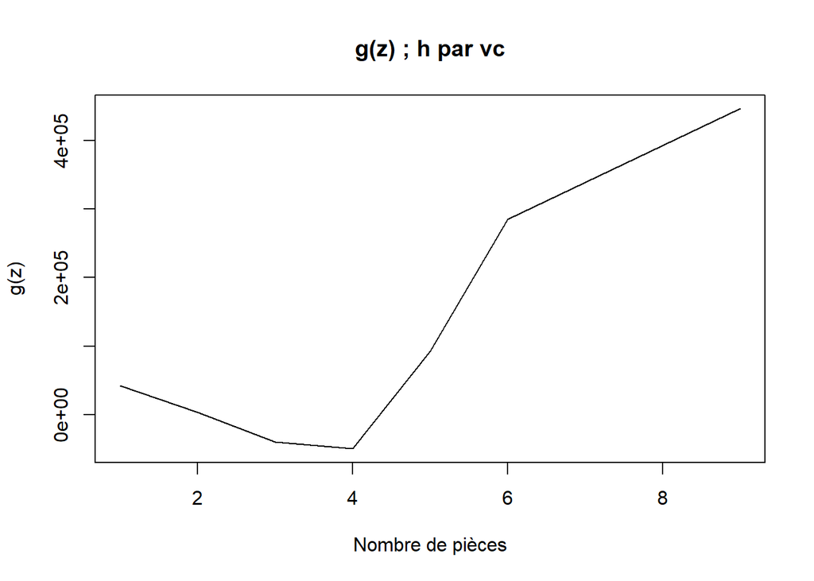